# Tests für unabhängige Stichproben - Lösungen

2020-12-17

**Daten einlesen**

```r
setwd("...")
load("fb20.rda")
```

**Daten aufbereiten**

```r
# Lieblingsfach als Faktor - falls es noch keiner war
if(is.factor(fb20$fach) == FALSE){
  fb20$fach <- factor(fb20$fach,
                      levels = 1:5,
                      labels = c('Allgemeine', 'Biologische', 'Entwicklung',
                                 'Klinische', 'Diag./Meth.'))
}

# Wohnort als Faktor - falls es noch keiner war
if(is.factor(fb20$ort) == FALSE){
  fb20$ort <- factor(fb20$ort,
                     levels = c(1, 2),
                     labels = c('Frankfurt', 'anderer'))
}

# Geschlecht als Faktor - falls es noch keiner war
if(is.factor(fb20$geschl)==FALSE){
  fb20$geschl <- factor(fb20$geschl,
                        levels=c(1,2,3),
                        labels=c('weiblich', 'maennlich', 'anderes'))
}
```

## Aufgabe 1

Unterscheiden sich Studierende, die sich für Allgemeine Psychologie (Variable “fach”) interessieren, im Persönlichkeitsmerkmal Intellekt (auch: Offenheit für neue Erfahrungen, “intell”) von Studierenden, die sich für Klinische Psychologie interessieren? Normalverteilung des Merkmals in der Population darf angenommen werden.

**Lösung**

**Deskriptivstatistische Beantwortung der Fragestellung: grafisch**

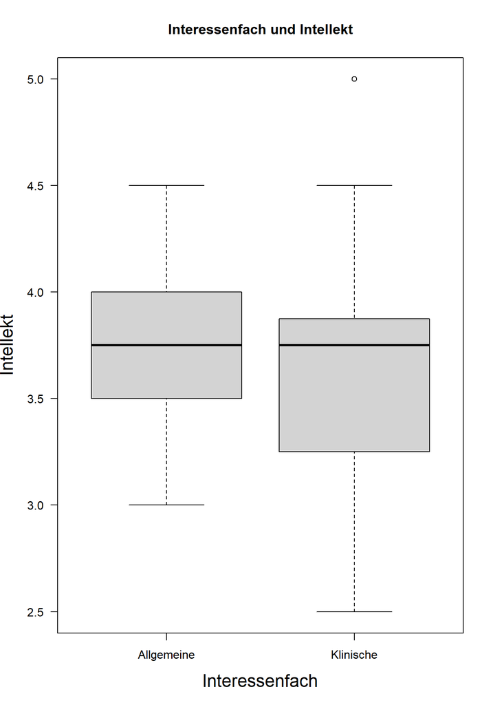

```r
data1 <- fb20[ (which(fb20$fach=="Allgemeine"|fb20$fach=="Klinische")), ]
data1$fach <- droplevels(data1$fach)
boxplot(data1$intel ~ data1$fach,
        xlab="Interessenfach", ylab="Intellekt",
        las=1, cex.lab=1.5,
        main="Interessenfach und Intellekt")
```

**Deskriptivstatistische Beantwortung der Fragestellung: statistisch**

```r
# Überblick

library(psych)
describeBy(data1$intel, data1$fach)
```

```
##
##  Descriptive statistics by group
## group: Allgemeine
##    vars  n mean   sd median trimmed  mad min max range skew kurtosis   se
## X1    1 23 3.72 0.39   3.75    3.72 0.37   3 4.5   1.5    0    -0.72 0.08
## ------------------------------------------------------------
## group: Klinische
##    vars  n mean   sd median trimmed  mad min max range skew kurtosis   se
## X1    1 28  3.6 0.66   3.75    3.57 0.56 2.5   5   2.5 0.29    -0.37 0.12
```

```r
# Berechnung der empirischen Standardabweichung

intel.A <- data1$intel[(data1$fach=="Allgemeine")]
sigma.A <- sd(intel.A)
n.A <- length(intel.A[!is.na(intel.A)])
sd.A <- sigma.A * sqrt((n.A-1) / n.A)
sd.A
```

```
## [1] 0.3780984
```

```r
intel.B <- data1$intel[(data1$fach=="Klinische")]
sigma.B <- sd(intel.B)
n.B <- length(intel.B[!is.na(intel.B)])
sd.B <- sigma.B * sqrt((n.B-1) / n.B)
sd.B
```

```
## [1] 0.6455178
```

Mittelwert der Allgemeinen Psychologen (*M* = 3.72, *SD* = 0.38) unterscheidet sich deskriptivstatistisch vom Mittelwert der Klinischen (*M* = 3.6, *SD* = 0.65).

**Voraussetzungsprüfung: Normalverteilung**

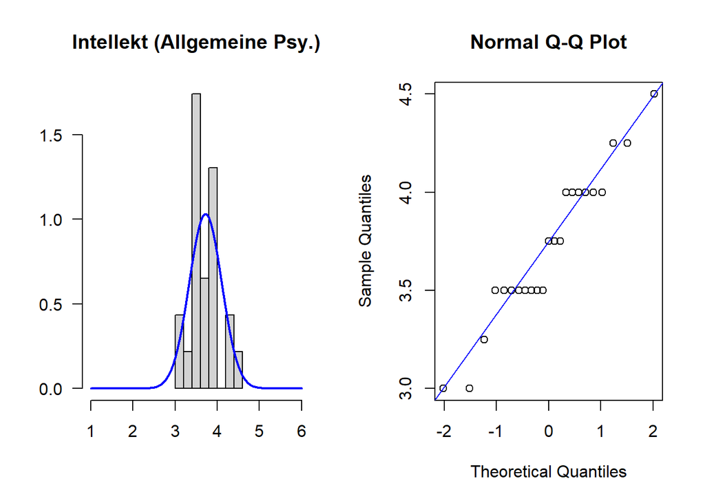

```r
par(mfrow=c(1,2))
intel.A <- data1[which(data1$fach=="Allgemeine"), "intel"]
hist(intel.A, xlim=c(1,6), main="Intellekt (Allgemeine Psy.)", xlab="", ylab="", las=1, prob=T)
curve(dnorm(x, mean=mean(intel.A, na.rm=T), sd=sd(intel.A, na.rm=T)), col="blue", lwd=2, add=T)
qqnorm(intel.A)
qqline(intel.A, col="blue")
```

$\rightarrow$ Entscheidung: Normalverteilung wird für Gruppe 1 (Allgemeine Psycholgie) angenommen

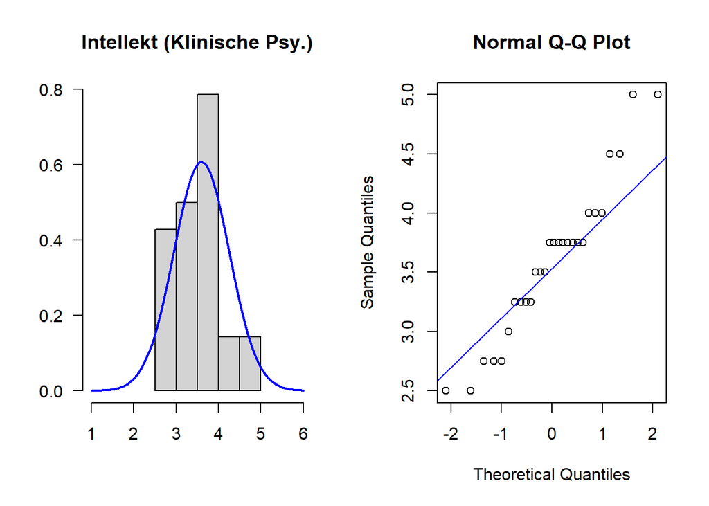

```r
par(mfrow=c(1,2))
intel.B <- data1[which(data1$fach=="Klinische"), "intel"]
hist(intel.B, xlim=c(1,6), main="Intellekt (Klinische Psy.)", xlab="", ylab="", las=1, prob=T)
curve(dnorm(x, mean=mean(intel.B, na.rm=T), sd=sd(intel.B, na.rm=T)), col="blue", lwd=2, add=T)
qqnorm(intel.B)
qqline(intel.B, col="blue")
```

$\rightarrow$ Entscheidung: Normalverteilung wird für Gruppe 2 (Klinische Psycholgie) nicht angenommen

**Hypothesen**

- Art des Effekts: Unterschiedshypothese
- Richtung des Effekts: Ungerichtet $\rightarrow$ ungerichtete Hypothesen
- Größe des Effekts: Unspezifisch

Hypthesenpaar (statistisch):

- $H_0$: $\mu_{Allgemeine} = \mu_{Klinische}$
- $H_1$: $\mu_{Allgemeine} \ne \mu_{Klinische}$

**Spezifikation des Signifikanzniveaus**

$\alpha = .05$

**Durchführung des Wilcoxon-Tests**

```r
wilcox.test(data1$intel ~ data1$fach,  # abhängige Variable ~ unabhängige Variable
       paired = F,                     # Stichproben sind unabhängig
       alternative = "two.sided",      # zweiseitige Testung
       conf.level = .95)               # alpha = .05
```

```
##
##  Wilcoxon rank sum test with continuity correction
##
## data:  data1$intel by data1$fach
## W = 370, p-value = 0.362
## alternative hypothesis: true location shift is not equal to 0
```

**Formales Berichten des Ergebnisses**

Es wurde untersucht, ob sich Studierende, die sich für Allgemeine Psychologie interessieren, im Persönlichkeitsmerkmal Intellekt (auch: Offenheit für neue Erfahrungen) von Studierenden, die sich für Klinische Psychologie interessieren, unterscheiden. Deskriptiv liegt ein solcher Unterschied vor: Die Mittelwerte betragen 3.72 (Allgemeine, *SD* = 0.38) und 3.60 (Klinische, *SD* = 0.65). Der entsprechende Wilcoxon-Test zeigt jedoch ein nicht signifikantes Ergebnis (*W* = 370, *p* = .362).

## Aufgabe 2

Sind Studierende, die außerhalb von Frankfurt wohnen (“ort”), zufriedener im Leben (“lz”) als diejenigen, die innerhalb von Frankfurt wohnen?

**Lösung**

**Deskriptivstatistische Beantwortung der Fragestellung: grafisch**

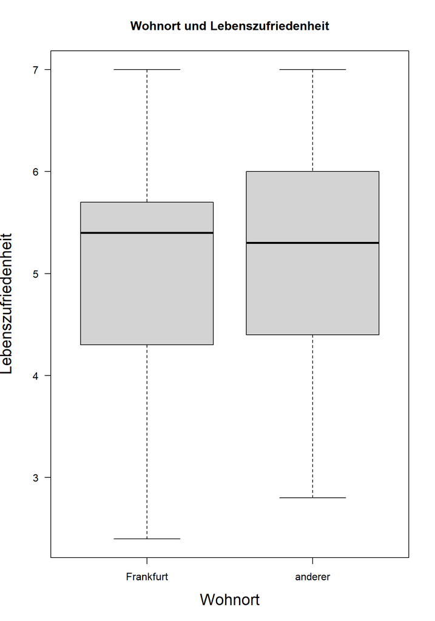

```r
boxplot(fb20$lz ~ fb20$ort,
        xlab="Wohnort", ylab="Lebenszufriedenheit",
        las=1, cex.lab=1.5,
        main="Wohnort und Lebenszufriedenheit")
```

**Deskriptivstatistische Beantwortung der Fragestellung: statistisch**

```r
library(psych)
describeBy(fb20$lz, fb20$ort)
```

```
##
##  Descriptive statistics by group
## group: Frankfurt
##    vars  n mean   sd median trimmed  mad min max range  skew kurtosis   se
## X1    1 40 5.05 1.13    5.4    5.14 0.89 2.4   7   4.6 -0.65    -0.09 0.18
## ------------------------------------------------------------
## group: anderer
##    vars  n mean   sd median trimmed  mad min max range  skew kurtosis   se
## X1    1 48 5.17 1.13    5.3     5.2 1.04 2.8   7   4.2 -0.29    -0.98 0.16
```

```r
summary(fb20[which(fb20$ort=="Frankfurt"), "lz"])
```

```
##    Min. 1st Qu.  Median    Mean 3rd Qu.    Max.    NA's
##    2.40    4.35    5.40    5.05    5.65    7.00       1
```

```r
summary(fb20[which(fb20$ort=="anderer"), "lz"])
```

```
##    Min. 1st Qu.  Median    Mean 3rd Qu.    Max.    NA's
##   2.800   4.400   5.300   5.167   6.000   7.000       1
```

Mittelwert der Nicht-Frankfurter ist deskriptiv höher als der der Frankfurter.

**Voraussetzungsprüfung: Normalverteilung**

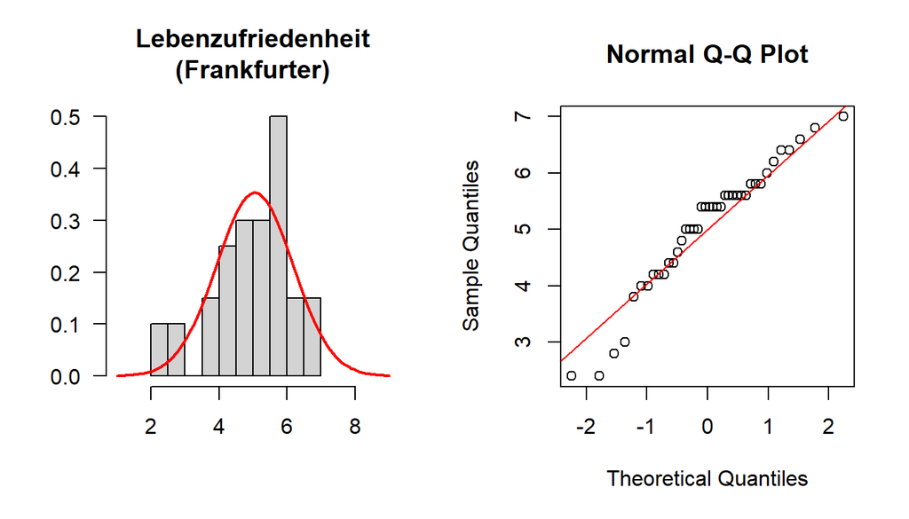

```r
par(mfrow=c(1,2))
lz.F <- fb20[which(fb20$ort=="Frankfurt"), "lz"]
hist(lz.F, xlim=c(1,9), main="Lebenzufriedenheit\n(Frankfurter)", xlab="", ylab="", las=1, prob=T)
curve(dnorm(x, mean=mean(lz.F, na.rm=T), sd=sd(lz.F, na.rm=T)), col="red", lwd=2, add=T)
qqnorm(lz.F)
qqline(lz.F, col="red")
```

$\rightarrow$ Entscheidung: Normalverteilung wird angenommmen

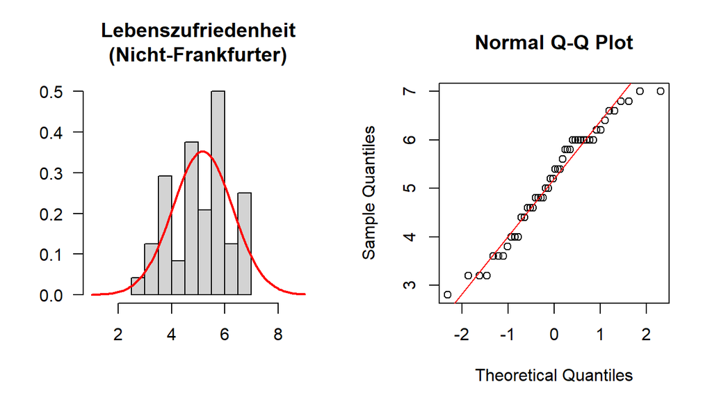

```r
par(mfrow=c(1,2))
lz.a <- fb20[which(fb20$ort=="anderer"), "lz"]
hist(lz.a, xlim=c(1,9), main="Lebenszufriedenheit\n(Nicht-Frankfurter)", xlab="", ylab="", las=1, prob=T)
curve(dnorm(x, mean=mean(lz.a, na.rm=T), sd=sd(lz.a, na.rm=T)), col="red", lwd=2, add=T)
qqnorm(lz.a)
qqline(lz.a, col="red")
```

$\rightarrow$ Entscheidung: Normalverteilung wird angenommmen

**Voraussetzungsprüfung: Varianzhomogenität**

```r
library(car)
leveneTest(fb20$lz ~ fb20$ort)
```

```
## Levene's Test for Homogeneity of Variance (center = median)
##       Df F value Pr(>F)
## group  1  0.4317 0.5129
##       86
```

*F*(1,86) = 0.43, *p* = .513 $\rightarrow$ Das Ergebnis ist nicht signifikant, die $H_0$ wird beibehalten und Varianzhomogenität angenommen.

**Hypothesen**

- Art des Effekts: Unterschiedshypothese
- Richtung des Effekts: Gerichtet $\rightarrow$ gerichtete Hypothesen
- Größe des Effekts: Unspezifisch

**Spezifikation des Signifikanzniveaus**

$\alpha = .05$

**Durchführung des *t*-Tests**

```r
levels(fb20$ort)
```

```
## [1] "Frankfurt" "anderer"
```

```r
t.test(fb20$lz ~ fb20$ort,           # abhängige Variable ~ unabhängige Variable
       paired = F,                   # Stichproben sind unabhängig
       alternative = "less",         # einseitige Testung: Gruppe1 (Frankfurter) < Gruppe2 (Nicht-Frankfurter)
       var.equal = T,                # Varianzhomogenität ist gegeben (-> Levene-Test)
       conf.level = .95)             # alpha = .05
```

```
##
##  Two Sample t-test
##
## data:  fb20$lz by fb20$ort
## t = -0.48201, df = 86, p-value = 0.3155
## alternative hypothesis: true difference in means between group Frankfurt and group anderer is less than 0
## 95 percent confidence interval:
##       -Inf 0.2857945
## sample estimates:
## mean in group Frankfurt   mean in group anderer
##                5.050000                5.166667
```

**Formales Berichten des Ergebnisses**

Es wurde untersucht, ob außerhalb von Frankfurt wohnende Studierende zufriedener im Leben sind als die in Frankfurt wohnenden. Deskriptiv zeigt sich tatsächlich, dass die Nicht-Frankfurter zufriedener sind (*M* = 5.17, *SD* = 1.13) als die Frankfurter (*M* = 5.05, *SD* = 1.13). Der *t*-Test zeigt jedoch ein nicht signifikantes Ergebnis (*t*(*df* = 86, eins.) = -.48, *p* = .316). Die Nullhypothese konnte nicht verworfen werden und wird beibehalten. Die Studierenden sind gleich zufrieden, unabhängig von deren Wohnort.

## Aufgabe 3

Ist die Wahrscheinlichkeit dafür, innerhalb von Frankfurt zu wohnen, die gleiche für weibliche wie für männliche Erstsemester-Studierende der Psychologie?

**Lösung**

Beide Variablen sind nominalskaliert $\rightarrow \chi^2$-Test

**Voraussetungen**

1. Die einzelnen Beobachtungen sind voneinander unabhängig $\rightarrow$ ok
2. Jede Person lässt sich eindeutig einer Kategorie bzw. Merkmalskombination zuordnen $\rightarrow$ ok
3. Zellbesetzung für alle $n_{ij}$ > 5 $\rightarrow$ Prüfung anhand von Häufigkeitstabelle

```r
fb20$geschlecht <- fb20$geschl[fb20$geschl=="weiblich"|fb20$geschl=="maennlich"]
fb20$geschlecht <- droplevels(fb20$geschlecht)
tab <- table(fb20$geschlecht, fb20$ort)
tab
```

```
##
##             Frankfurt anderer
##   weiblich         33      37
##   maennlich         8      12
```

$\rightarrow n_{ij}$ > 5 in allen Zellen gegeben

**Hypothesen**

- Art des Effekts: Zusammenhangshypothese
- Richtung des Effekts: Ungerichtet
- Größe des Effekts: Unspezifisch

Hyothesenpaar (inhaltlich):

- $H_0$: Weibliche und männliche Studierende der Psychologie wohnen mit gleicher Wahrscheinlichkeit innerhalb bzw. außerhalb von Frankfurt.
- $H_1$: Weibliche und männliche Studierende der Psychologie unterscheiden sich in der Wahrscheinlichkeit, innerhalb bzw. außerhalb von Frankfurt zu wohnen.

Hypothesenpaar (statistisch):

- $H_0$: $\pi_{ij} = \pi_{i\bullet} \cdot \pi_{\bullet j}$
- $H_1$: $\pi_{ij} \neq \pi_{i\bullet} \cdot \pi_{\bullet j}$

**Durchführung des $\chi^2$-Test in R**

```r
chisq.test(tab, correct=FALSE)
```

```
##
##  Pearson's Chi-squared test
##
## data:  tab
## X-squared = 0.31999, df = 1, p-value = 0.5716
```

$\chi^2 = 0.320, df = 1, p = .572 \rightarrow H_0$

**Effektstärke Phi ($\phi$)**

```r
library(psych)
phi(tab)
```

```
## [1] 0.06
```

**Ergebnisinterpretation**

Es wurde untersucht, ob sich männliche und weibliche Studierende in ihrem Wohnort (Frankfurt vs. außerhalb) unterscheiden. Zur Beantwortung der Fragestellung wurde ein Vierfelder-Chi-Quadrat-Test für unabhängige Stichproben berechnet. Der Zusammenhang zwischen Wohnort und Geschlecht ist nicht signifikant ($\chi^2(1) = 0.320, p = .572$), somit wird die Nullhypothese beibehalten. Der Effekt ist von vernachlässigbarer Stärke ($\phi = .06$). Männliche und weibliche Studierende wohnen also mit gleicher Wahrscheinlichkeit in Frankfurt bzw. außerhalb von Frankfurt.